# Homework 5

## Exercise 3

```r
religions_denoms <- gss_cat %>%
  select(relig, denom) %>%
  filter(!denom == "Not applicable") %>%
  filter(!denom == "No denomination") %>%
  filter(!denom == "No answer") %>%
  filter(!denom == "Don't know") %>%
  arrange(desc(relig))

religions_denoms1 <- gss_cat %>%
  select(relig, denom) %>%
  filter(!denom == "Not applicable") %>%
  filter(!denom == "No denomination") %>%
  filter(!denom == "No answer") %>%
  filter(!denom == "Don't know") %>%
  arrange((relig))


religions_denoms
```

```
## # A tibble: 9,559 × 2
##    relig      denom
##    <fct>      <fct>
##  1 Protestant Southern baptist
##  2 Protestant Baptist-dk which
##  3 Protestant Southern baptist
##  4 Protestant Lutheran-mo synod
##  5 Protestant Other
##  6 Protestant Southern baptist
##  7 Protestant Other
##  8 Protestant Southern baptist
##  9 Protestant United methodist
## 10 Protestant Baptist-dk which
## # ℹ 9,549 more rows
```

```r
religions_denoms1
```

```
## # A tibble: 9,559 × 2
##    relig      denom
##    <fct>      <fct>
##  1 Protestant Southern baptist
##  2 Protestant Baptist-dk which
##  3 Protestant Southern baptist
##  4 Protestant Lutheran-mo synod
##  5 Protestant Other
##  6 Protestant Southern baptist
##  7 Protestant Other
##  8 Protestant Southern baptist
##  9 Protestant United methodist
## 10 Protestant Baptist-dk which
## # ℹ 9,549 more rows
```

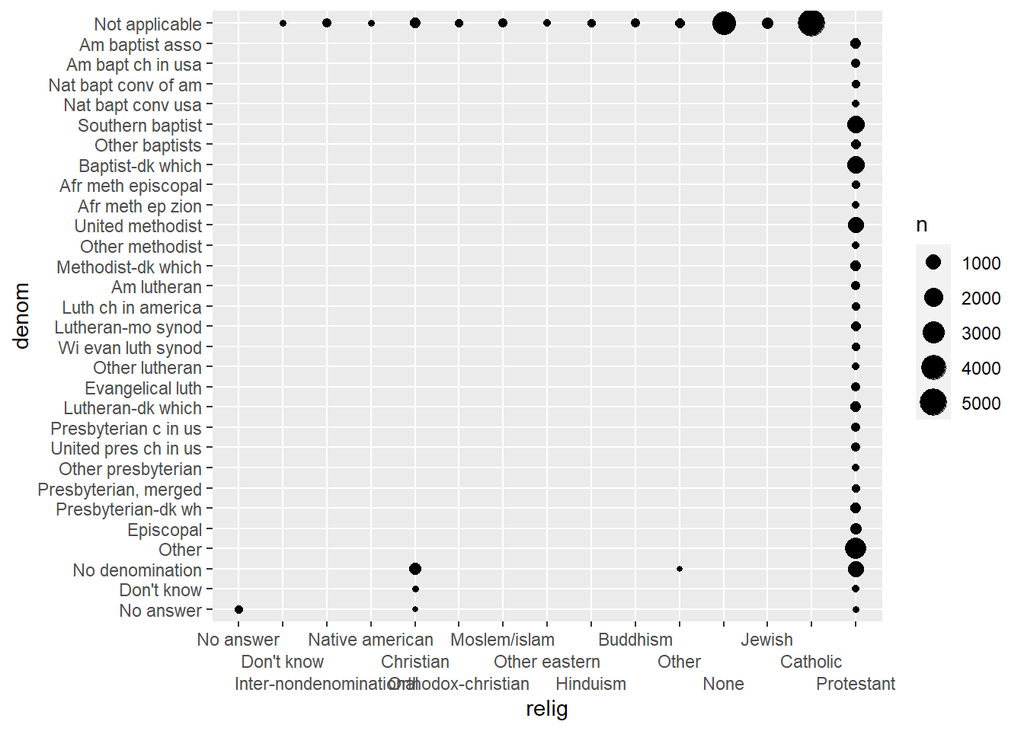

```r
ggplot(gss_cat, mapping = aes(relig, denom)) +
  geom_count() +
  scale_x_discrete(guide = guide_axis(n.dodge=3))
```

I have shown code to provide a table and a graph that I think show that the denom category applies to the protestant religion. The table is filled only by protestants after the non-applicable answers are removed. This can be proved by arranging it by religion and moving to the end of the dataset, which still shows protestant.

# Chapter 12 (Pg. 232)

## Exercise 2

```r
?gss_cat
```

```
## starting httpd help server ... done
```

When looking at the help documentation for gss_cat, we can determine that the variables marital, race, relig, and denom are arbitrary and the variables rincome, and partyid are principled

# Chapter 12 (Pg. 235)

## Exercise 1

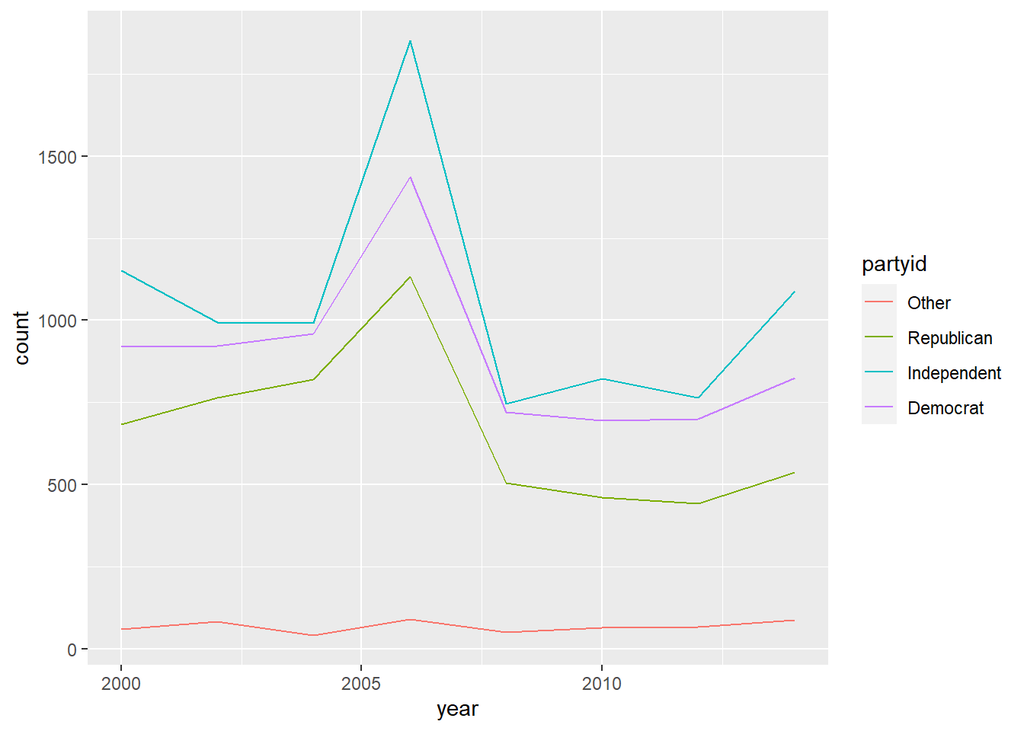

```r
gss_cat %>%
 mutate(partyid = fct_recode(partyid,
 "Republican" = "Strong republican",
 "Republican" = "Not str republican",
 "Independent" = "Ind,near rep",
 "Independent" = "Ind,near dem",
 "Democrat" = "Not str democrat",
 "Democrat" = "Strong democrat",
 "Other" = "No answer",
 "Other" = "Don't know",
 "Other" = "Other party"
 )) %>%
  group_by(partyid, year) %>%
  summarize(count = n()) %>%
  ggplot(aes(year, count, color = partyid)) +
  geom_line()
```

This plot shows that over time, each party has a spike in 2006, especially the independent party. However, between the democrat and republican party, there has not been any change in which has more affiliation throughout the years.

## Exercise 2

```r
gss_cat %>%
  mutate(rincome = fct_lump(rincome, n = 5)) %>%
  count(rincome, sort = TRUE) %>%
  print(n = Inf)
```

```
## # A tibble: 6 × 2
##   rincome            n
##   <fct>          <int>
## 1 $25000 or more  7363
## 2 Not applicable  7043
## 3 Other           3578
## 4 $20000 - 24999  1283
## 5 $10000 - 14999  1168
## 6 $15000 - 19999  1048
```

The code shown is an example of how we could collapse rincome into a small set of categories.